# Resolution functions

The purpose of the resolution function is to enable the `easyreflectometry` model to quantify the experimental uncertainties in wavelength and incident angle. When determining reflectivity the resolution function defines the smearing to apply. For a given Q-point such smearing is applied by determining an average of the neighboring Q-point weigthed by a normal distribution, which has a Q-point dependent Full Width at the Half Maximum (FWHM) that again is defined by the resolution function.

Often we rely on a resolution function that has a simple functional dependecy of the Q-point. By this is understood that the applied smearing in an Q point-has a FWHM that is given as a percentage of the value of the Q-point.

Alternatively the FWHM value might be determined and declared directly for each measured Q-point. When this is the case the provided Q-points and the corresponding FWHM values can be used to declare a linear spline function and thereby enable a determination of the reflectivity at an arbitrary point within the provided range of discrete Q-points.

## Setup

First configure matplotlib to place figures in notebook and import needed modules. Note that the plot function needs installation of `plopp` seperately or installation of `easyreflectometry[dev]`

```python
%matplotlib inline
```

%matplotlib inline

```python
import matplotlib.pyplot as plt
import numpy as np
import pooch
import refnx
import scipp as sc

import easyreflectometry
from easyreflectometry.calculators import CalculatorFactory
from easyreflectometry.data import load
from easyreflectometry.model import LinearSpline
from easyreflectometry.model import Model
from easyreflectometry.model import PercentageFwhm
from easyreflectometry.model import Pointwise
from easyreflectometry.plot import plot
from easyreflectometry.sample import Layer
from easyreflectometry.sample import Material
from easyreflectometry.sample import Multilayer
from easyreflectometry.sample import Sample
```

import matplotlib.pyplot as plt import numpy as np import pooch import refnx import scipp as sc import easyreflectometry from easyreflectometry.calculators import CalculatorFactory from easyreflectometry.data import load from easyreflectometry.model import LinearSpline from easyreflectometry.model import Model from easyreflectometry.model import PercentageFwhm from easyreflectometry.model import Pointwise from easyreflectometry.plot import plot from easyreflectometry.sample import Layer from easyreflectometry.sample import Material from easyreflectometry.sample import Multilayer from easyreflectometry.sample import Sample

For reference we fetch the version of the software packages we are using.

```python
print(f'numpy: {np.__version__}')
print(f'scipp: {sc.__version__}')
print(f'easyreflectometry: {easyreflectometry.__version__}')
print(f'refnx: {refnx.__version__}')
```

print(f'numpy: {np.__version__}') print(f'scipp: {sc.__version__}') print(f'easyreflectometry: {easyreflectometry.__version__}') print(f'refnx: {refnx.__version__}')

```
numpy: 2.4.4
scipp: 26.3.1
easyreflectometry: 999.0.0
refnx: 0.1.63
```

## Reading in measured data

The data that we will investigate in this tutorial was generated with `Refnx` and are stored in `.ort` [format file](https://github.com/reflectivity/file_format/blob/master/specification.md) files. In this tutorial we are investigation how we can include resolution effects when simulating and reproducing data measured in an experiment. For an `.ort` file the resoultion data for reflectivity is stored in the fourth column.

IMPORTANT when using `easyreflectometry` functionality for loading an `.ort` file we store the resolution data as a variance (squared value). As a consequence one needs to take the squareroot of the loaded data to recover the raw values (fourth column). We use `pooch` to fetch the file from the repository.

```python
file_path_0 = pooch.retrieve(
    # Fetch test data from the easyscience/reflectometry data repository
    url='https://raw.githubusercontent.com/easyscience/reflectometry/master/data/mod_pointwise_two_layer_sample_dq-0.0.ort',
    known_hash='f8a3e7007b83f0de4e2c761134e7d1c55027f0099528bd56f746b50349369f50',
)
file_path_1 = pooch.retrieve(
    # Fetch test data from the easyscience/reflectometry data repository
    url='https://raw.githubusercontent.com/easyscience/reflectometry/master/data/mod_pointwise_two_layer_sample_dq-1.0.ort',
    known_hash='9d81a512cbe45f923806ad307e476b27535614b2e08a2bf0f4559ab608a34f7a',
)
file_path_10 = pooch.retrieve(
    # Fetch test data from the easyscience/reflectometry data repository
    url='https://raw.githubusercontent.com/easyscience/reflectometry/master/data/mod_pointwise_two_layer_sample_dq-10.0.ort',
    known_hash='991395c0b6a91bf60c12d234c645143dcac1cab929944fc4e452020d44b787ad',
)
dict_reference = {}
dict_reference['0'] = load(file_path_0)
dict_reference['1'] = load(file_path_1)
dict_reference['10'] = load(file_path_10)
```

file_path_0 = pooch.retrieve( # Fetch test data from the easyscience/reflectometry data repository url='https://raw.githubusercontent.com/easyscience/reflectometry/master/data/mod_pointwise_two_layer_sample_dq-0.0.ort', known_hash='f8a3e7007b83f0de4e2c761134e7d1c55027f0099528bd56f746b50349369f50', ) file_path_1 = pooch.retrieve( # Fetch test data from the easyscience/reflectometry data repository url='https://raw.githubusercontent.com/easyscience/reflectometry/master/data/mod_pointwise_two_layer_sample_dq-1.0.ort', known_hash='9d81a512cbe45f923806ad307e476b27535614b2e08a2bf0f4559ab608a34f7a', ) file_path_10 = pooch.retrieve( # Fetch test data from the easyscience/reflectometry data repository url='https://raw.githubusercontent.com/easyscience/reflectometry/master/data/mod_pointwise_two_layer_sample_dq-10.0.ort', known_hash='991395c0b6a91bf60c12d234c645143dcac1cab929944fc4e452020d44b787ad', ) dict_reference = {} dict_reference['0'] = load(file_path_0) dict_reference['1'] = load(file_path_1) dict_reference['10'] = load(file_path_10)

```
Downloading data from 'https://raw.githubusercontent.com/easyscience/reflectometry/master/data/mod_pointwise_two_layer_sample_dq-0.0.ort' to file '/home/runner/.cache/pooch/64288b1ef54b9fed81676e985ce01b5b-mod_pointwise_two_layer_sample_dq-0.0.ort'.
```

```
Downloading data from 'https://raw.githubusercontent.com/easyscience/reflectometry/master/data/mod_pointwise_two_layer_sample_dq-1.0.ort' to file '/home/runner/.cache/pooch/d8b588889bb93a0d9ebd820857782c97-mod_pointwise_two_layer_sample_dq-1.0.ort'.
```

```
Downloading data from 'https://raw.githubusercontent.com/easyscience/reflectometry/master/data/mod_pointwise_two_layer_sample_dq-10.0.ort' to file '/home/runner/.cache/pooch/0295dd5091bf9476fe53d27bcb144c98-mod_pointwise_two_layer_sample_dq-10.0.ort'.
```

```python
dict_reference['0']
```

dict_reference['0']

scipp.DataGroup

()

- data

  dict

  ()

  {'R_0': <scipp.Variable> (Qz_0: 195) float64 <no unit> [0.935884, 0.9...

- coords

  dict

  ()

  {'Qz_0': <scipp.Variable> (Qz_0: 195) float64 [1/Å] [0.0111192, 0....

- attrs

  dict

  ()

  {'R_0': {'orso_header': <scipp.Variable> () PyObject <no unit> {'data_...

As an example we can plot the reference data without any resolution effects.

```python
plot(dict_reference['0'])
```

plot(dict_reference['0'])

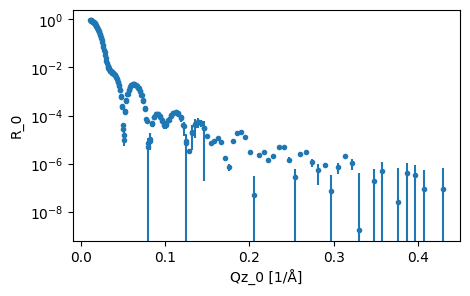

## Building our model

The system that was used to produce the data shown above is based on a silicon subphase with two layers upon it. These two layers are charachterized by having a scattering length density (SLD) of respectively 4 and 8. Both layers have a rougness of 2 but their thicknesses are 100 and 150 angstrom respectively. We show the model that will be used graphically below.

[figure not shown]

A slab model description of the two layer.

To construct such a layer structure, first we create each of the materials, the associated layers, and the sub and super phases.

```python
sld_4 = Material(sld=4.0, isld=0, name='Sld 4')
sld_8 = Material(sld=8.0, isld=0, name='Sld 8')
vacuum = Material(sld=0, isld=0, name='Vacuum')
si = Material(sld=2.047, isld=0, name='Si')
```

sld_4 = Material(sld=4.0, isld=0, name='Sld 4') sld_8 = Material(sld=8.0, isld=0, name='Sld 8') vacuum = Material(sld=0, isld=0, name='Vacuum') si = Material(sld=2.047, isld=0, name='Si')

```python
sld_4_layer = Layer(material=sld_4, thickness=100, roughness=2, name='SLD 4 Layer')
sld_8_layer = Layer(material=sld_8, thickness=150, roughness=2, name='SLD 8 Layer')
superphase = Layer(material=vacuum, thickness=0, roughness=0, name='Vacuum Superphase')
subphase = Layer(material=si, thickness=0, roughness=2, name='Si Subphase')
```

sld_4_layer = Layer(material=sld_4, thickness=100, roughness=2, name='SLD 4 Layer') sld_8_layer = Layer(material=sld_8, thickness=150, roughness=2, name='SLD 8 Layer') superphase = Layer(material=vacuum, thickness=0, roughness=0, name='Vacuum Superphase') subphase = Layer(material=si, thickness=0, roughness=2, name='Si Subphase')

Then, to produce the two layered structure, we use the `Multilayer` assembly type.

```python
two_layers = Multilayer([sld_4_layer, sld_8_layer], name='SLD 4/8 Layer')
two_layers
```

two_layers = Multilayer([sld_4_layer, sld_8_layer], name='SLD 4/8 Layer') two_layers

```
SLD 4/8 Layer:
  SLD 4 Layer/SLD 8 Layer:
  - SLD 4 Layer:
      material:
        Sld 4:
          sld: 4.000e-6 1/Å^2
          isld: 0.000e-6 1/Å^2
      thickness: 100.000 Å
      roughness: 2.000 Å
  - SLD 8 Layer:
      material:
        Sld 8:
          sld: 8.000e-6 1/Å^2
          isld: 0.000e-6 1/Å^2
      thickness: 150.000 Å
      roughness: 2.000 Å
```

From this, we can construct our structure and combine this with a scaling and background.

```python
sample = Sample(Multilayer(superphase), two_layers, Multilayer(subphase), name='Two Layer Sample')
model = Model(
    sample=sample,
    scale=1,
    background=0,
    name='Two Layer Model',
)
```

sample = Sample(Multilayer(superphase), two_layers, Multilayer(subphase), name='Two Layer Sample') model = Model( sample=sample, scale=1, background=0, name='Two Layer Model', )

## Set the calculation engine

We will use the default [Refnx](https://refnx.readthedocs.io/) calculator for our analysis.

```python
interface = CalculatorFactory()
model.interface = interface
print(interface.current_interface.name)
```

interface = CalculatorFactory() model.interface = interface print(interface.current_interface.name)

```
refnx
```

## Resolution functions

We can now define the different resoultion functions.

```python
resolution_function_dict = {}
resolution_function_dict['0'] = LinearSpline(
    q_data_points=dict_reference['0']['coords']['Qz_0'].values,
    fwhm_values=np.sqrt(dict_reference['0']['coords']['Qz_0'].variances),
)

resolution_function_dict['1'] = LinearSpline(
    q_data_points=dict_reference['1']['coords']['Qz_0'].values,
    fwhm_values=np.sqrt(dict_reference['1']['coords']['Qz_0'].variances),
)

resolution_function_dict['10'] = LinearSpline(
    q_data_points=dict_reference['10']['coords']['Qz_0'].values,
    fwhm_values=np.sqrt(dict_reference['10']['coords']['Qz_0'].variances),
)
```

resolution_function_dict = {} resolution_function_dict['0'] = LinearSpline( q_data_points=dict_reference['0']['coords']['Qz_0'].values, fwhm_values=np.sqrt(dict_reference['0']['coords']['Qz_0'].variances), ) resolution_function_dict['1'] = LinearSpline( q_data_points=dict_reference['1']['coords']['Qz_0'].values, fwhm_values=np.sqrt(dict_reference['1']['coords']['Qz_0'].variances), ) resolution_function_dict['10'] = LinearSpline( q_data_points=dict_reference['10']['coords']['Qz_0'].values, fwhm_values=np.sqrt(dict_reference['10']['coords']['Qz_0'].variances), )

## Simulations

The next step is to visualise how the resolution functions affect the model.  
Furthermore, we compare the here determined reflectivities (Resolution) and the ones that were determined in `Refnx` (Reference).

```python
for key in resolution_function_dict.keys():
    reference_coords = dict_reference[key]['coords']['Qz_0'].values
    reference_data = dict_reference[key]['data']['R_0'].values
    model_coords = np.linspace(
        start=min(reference_coords),
        stop=max(reference_coords),
        num=1000,
    )
    model.resolution_function = resolution_function_dict[key]
    model_data = model.interface().reflectity_profile(
        model_coords,
        model.unique_name,
    )
    plt.plot(model_coords, model_data, 'k-', label=f'Resolution: {key}%')
    plt.plot(reference_coords, reference_data, 'rx', label='Reference')
    ax = plt.gca()
    ax.set_xlim([-0.01, 0.45])
    ax.set_ylim([1e-10, 2.5])
    plt.legend()
    plt.yscale('log')
    plt.show()
```

for key in resolution_function_dict.keys(): reference_coords = dict_reference[key]['coords']['Qz_0'].values reference_data = dict_reference[key]['data']['R_0'].values model_coords = np.linspace( start=min(reference_coords), stop=max(reference_coords), num=1000, ) model.resolution_function = resolution_function_dict[key] model_data = model.interface().reflectity_profile( model_coords, model.unique_name, ) plt.plot(model_coords, model_data, 'k-', label=f'Resolution: {key}%') plt.plot(reference_coords, reference_data, 'rx', label='Reference') ax = plt.gca() ax.set_xlim([-0.01, 0.45]) ax.set_ylim([1e-10, 2.5]) plt.legend() plt.yscale('log') plt.show()

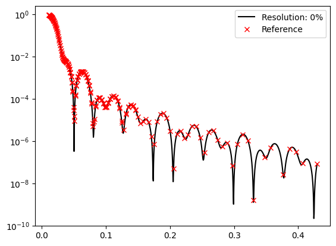

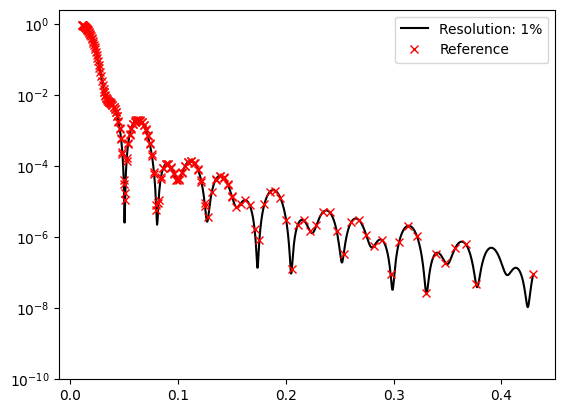

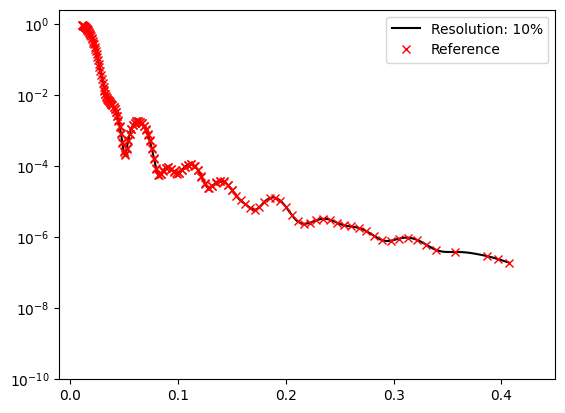

From the plots it is apparent that an increasing resolution flattens the reflectivity profile.

## Afterthoughts

As a last task we will compare the reflectivity determined using a percentage resolution function and a point-wise function. We should recall that the "experimental" data was generated using `Refnx`.

By comparing the reflectivities determined using a resolution function with a FWHM of 1.0% and the point-wise width constructed from the data in a `.ort` file, it is apparent that this reference data also was constructed using a resolution function of 1.0%.

```python
key = '1'
reference_coords = dict_reference[key]['coords']['Qz_0'].values
reference_data = dict_reference[key]['data']['R_0'].values
model_coords = np.linspace(
    start=min(reference_coords),
    stop=max(reference_coords),
    num=1000,
)

model.resolution_function = resolution_function_dict[key]
model_data = model.interface().reflectity_profile(
    model_coords,
    model.unique_name,
)
plt.plot(model_coords, model_data, 'k-', label='Variable', linewidth=5)

model.resolution_function = PercentageFwhm(1.0)
model_data = model.interface().reflectity_profile(
    model_coords,
    model.unique_name,
)
plt.plot(model_coords, model_data, 'r-', label='Percentage')

ax = plt.gca()
ax.set_xlim([-0.01, 0.45])
ax.set_ylim([1e-10, 2.5])
plt.legend()
plt.yscale('log')
plt.show()
```

key = '1' reference_coords = dict_reference[key]['coords']['Qz_0'].values reference_data = dict_reference[key]['data']['R_0'].values model_coords = np.linspace( start=min(reference_coords), stop=max(reference_coords), num=1000, ) model.resolution_function = resolution_function_dict[key] model_data = model.interface().reflectity_profile( model_coords, model.unique_name, ) plt.plot(model_coords, model_data, 'k-', label='Variable', linewidth=5) model.resolution_function = PercentageFwhm(1.0) model_data = model.interface().reflectity_profile( model_coords, model.unique_name, ) plt.plot(model_coords, model_data, 'r-', label='Percentage') ax = plt.gca() ax.set_xlim([-0.01, 0.45]) ax.set_ylim([1e-10, 2.5]) plt.legend() plt.yscale('log') plt.show()

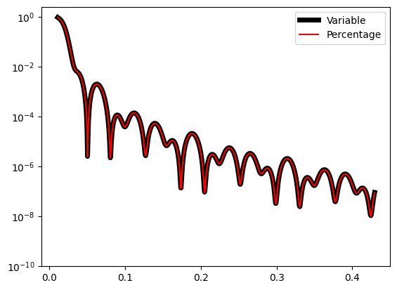

```python
key = '1'
reference_coords = dict_reference[key]['coords']['Qz_0'].values
reference_variances = dict_reference[key]['coords']['Qz_0'].variances
reference_data = dict_reference[key]['data']['R_0'].values
model_coords = np.linspace(
    start=min(reference_coords),
    stop=max(reference_coords),
    num=1000,
)

model.resolution_function = resolution_function_dict[key]
model_data = model.interface().reflectity_profile(
    model_coords,
    model.unique_name,
)
plt.plot(model_coords, model_data, 'k-', label='Variable', linewidth=5)

# The Pointwise resolution is built from the data triple [Qz, R, sQz],
# where sQz is the variance of Qz. The width sqrt(sQz) is interpolated onto q.
data_points = []
data_points.append(reference_coords)  # Qz
data_points.append(reference_data)  # R
data_points.append(reference_variances)  # sQz (variance of Qz)
model.resolution_function = Pointwise(q_data_points=data_points)
model_data = model.interface().reflectity_profile(
    model_coords,
    model.unique_name,
)
plt.plot(model_coords, model_data, 'r-', label='Pointwise')
plt.plot(reference_coords, reference_data, 'bx', label='Reference', markersize=4)

ax = plt.gca()
ax.set_xlim([-0.01, 0.45])
ax.set_ylim([1e-10, 2.5])
plt.legend()
plt.yscale('log')
plt.show()
```

key = '1' reference_coords = dict_reference[key]['coords']['Qz_0'].values reference_variances = dict_reference[key]['coords']['Qz_0'].variances reference_data = dict_reference[key]['data']['R_0'].values model_coords = np.linspace( start=min(reference_coords), stop=max(reference_coords), num=1000, ) model.resolution_function = resolution_function_dict[key] model_data = model.interface().reflectity_profile( model_coords, model.unique_name, ) plt.plot(model_coords, model_data, 'k-', label='Variable', linewidth=5) # The Pointwise resolution is built from the data triple [Qz, R, sQz], # where sQz is the variance of Qz. The width sqrt(sQz) is interpolated onto q. data_points = [] data_points.append(reference_coords) # Qz data_points.append(reference_data) # R data_points.append(reference_variances) # sQz (variance of Qz) model.resolution_function = Pointwise(q_data_points=data_points) model_data = model.interface().reflectity_profile( model_coords, model.unique_name, ) plt.plot(model_coords, model_data, 'r-', label='Pointwise') plt.plot(reference_coords, reference_data, 'bx', label='Reference', markersize=4) ax = plt.gca() ax.set_xlim([-0.01, 0.45]) ax.set_ylim([1e-10, 2.5]) plt.legend() plt.yscale('log') plt.show()

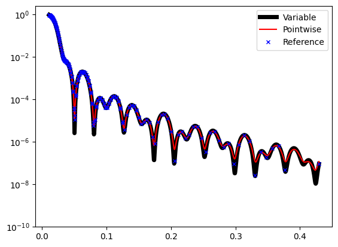